# User-defined MCMC samplers (spatial capture-recapture example)

NIMBLE training materials module

NIMBLE Development Team

# Introduction

NIMBLE’s MCMC system was designed to be extensible. It’s easy for users to add samplers and use them right away for their models.

Samplers and MCMC configuration functions for specific models could then be distributed as a package.

We’ll use a spatial capture-recapture example to illustrate writing and using new samplers.

The example is from Chapter 7 of Royle and Dorazio (2009)[^1], which draws upon Royle and Gardner. The example simulates and then fits simple camera trap data.

# Example setup

- N=28 animals are simulated in an arena of size 19 x 19.
- Some will never be seen. A goal is to estimate N.
- 100 cameras on a grid at locations 4:13 x 4:13
- 0:3 and 14:18 are buffers (not sure why they’re asymmetric, but that’s what the example code seems to do).
- Detection probability decreases as a bell curve (Gaussian) with distance
- For animal i at trap j:
  - detection rate = `Eo = lam0 * exp(-Distance^2 / sigma)`. (It is not written as `sigma^2`).
  - Probability of at least one detection in a period = `pmean = 1-exp(-Eo)`
  - Number of detections `y` is binomial from `J` sampling periods.

# BUGS code from Royle & Dorazio

```r
scrCode <- nimbleCode({
    sigma~dunif(0, 15)
    lam0~dgamma(.1,.1)
    psi~dunif(0, 1)

    for (i in 1:M){
        z[i] ~ dbern(psi)
    SX[i] ~ dunif(xl, xu)
    SY[i] ~ dunif(yl, yu)

        for(j in 1:ntraps) {
            D2[i,j] <- pow(SX[i]-trapmat[j,1], 2) + pow(SY[i]-trapmat[j,2], 2)
            Eo[i,j] <- lam0*exp(-D2[i,j]/sigma)
            pmean[i,j] <- 1-(exp(-Eo[i,j]))
            tmp[i,j] <- pmean[i,j]*z[i]
            y[i,j] ~ dbin(tmp[i,j],J)
        }
    }
    N<-sum(z[1:M])
})
```

# Think like a graph to re-write the model

Notice that every time `SX[i]` or `SY[i]` are modified, all of the following will always need recalculation:

- All distances to animal `i`: `D2[i, 1:ntraps]`
- All downstream quantities for animal i: `Eo[i, 1:ntraps]`, `pmean[i, 1:ntraps]`, and `tmp[i, 1:ntraps]`

We can rewrite the model using vectorized declarations in NIMBLE to take advantage of our understanding of the graph:

*In the current NIMBLE release, this model should build faster than in previous versions, but in an upcoming release all models should build even more faster so the build times will be less concerning.*

```r
scrCode2 <- nimbleCode({
    sigma~dunif(0, 15)
    lam0~dgamma(.1,.1)
    psi~dunif(0, 1)

    for (i in 1:M){
        z[i] ~ dbern(psi)
    SX[i] ~ dunif(xl, xu)
    SY[i] ~ dunif(yl, yu)
        D2[i,1:ntraps] <- pow(SX[i]-trapmat[1:ntraps,1], 2) +
                          pow(SY[i]-trapmat[1:ntraps,2],2)
        Eo[i,1:ntraps] <- lam0*exp(-D2[i,1:ntraps]/sigma)
        pmean[i,1:ntraps] <- 1-(exp(-Eo[i,1:ntraps]))
        tmp[i,1:ntraps] <- pmean[i,1:ntraps]*z[i]
        for(j in 1:ntraps) {
            y[i,j]~dbin(tmp[i,j],J)
        }
    }
    N<-sum(z[1:M])
})

## will run below:
## scrModel2 <- nimbleModel(scrCode2, constants = list(M = M, ntraps = ntraps,
##                                                   J = J,
##                                                   xl = xl, yl = yl,
##                                                   xu = xu, yu = yu),
##                                  data = list(trapmat = trapmat), check = FALSE)
```

# Simulate using NIMBLE

Often for a simulation study people re-write their model for simulation in R. That is what R&D’s book code does.

We can use NIMBLE’s `simulate` function instead.

```r
## From Royle & Dorazio:
sigma=3
## beta=1 ## beta is never used so must have been a typo in book code
lam0=.6
J=10          # number of capture periods
llx=0
upx=18
xl=llx
yl=llx
yu=upx
xu=upx

#Create a 10x10 grid of traps

x=4:13
y=4:13
locs=expand.grid(x,y)
ntraps=dim(locs)[1] ## thats 10x10 = 100 cameras
trapmat=as.matrix(locs)

## Use NIMBLE:
M <- 128
scrModel2 <- nimbleModel(scrCode2, constants = list(M = M, ntraps = ntraps, J = J,
                                                  xl = xl, yl = yl,
                                                  xu = xu, yu = yu),
                                 data = list(trapmat = trapmat), check = FALSE)
```

```
## defining model...
```

```
## building model...
```

```
## setting data and initial values...
```

```
## model building finished
```

```r
scrModel2$sigma <- sigma
scrModel2$lam0 <- lam0
scrModel2$z <- c(rep(1, 28), rep(0, 100)) ## R&D simulate 28 animals.
set.seed(123)
scrModel2$simulate( scrModel2$getDependencies(c('SX','SY'), downstream = TRUE))
dim(scrModel2$y)
```

```
## [1] 128 100
```

```r
scrModel2$y[1:3,] ## camera detections for first three real animals
```

```
##      [,1] [,2] [,3] [,4] [,5] [,6] [,7] [,8] [,9] [,10] [,11] [,12] [,13]
## [1,]    1    2    2    2    1    0    0    0    0     0     0     0     0
## [2,]    0    0    0    0    0    0    0    0    0     0     0     0     0
## [3,]    0    0    0    0    0    0    0    0    0     0     0     0     0
##      [,14] [,15] [,16] [,17] [,18] [,19] [,20] [,21] [,22] [,23] [,24]
## [1,]     0     0     0     0     0     0     0     1     0     0     0
## [2,]     0     0     0     0     0     0     0     0     0     0     0
## [3,]     0     0     0     0     0     0     0     0     0     0     0
##      [,25] [,26] [,27] [,28] [,29] [,30] [,31] [,32] [,33] [,34] [,35]
## [1,]     0     0     0     0     0     0     0     0     0     0     0
## [2,]     0     0     0     0     0     0     0     0     0     0     0
## [3,]     0     0     0     0     0     0     0     0     0     0     0
##      [,36] [,37] [,38] [,39] [,40] [,41] [,42] [,43] [,44] [,45] [,46]
## [1,]     0     0     0     0     0     0     0     0     0     0     0
## [2,]     0     0     0     0     0     0     0     0     0     0     0
```

[output cut: 21 more lines]

```r
scrModel2$y[29:31,] ## zeros in augmentation range
```

```
##      [,1] [,2] [,3] [,4] [,5] [,6] [,7] [,8] [,9] [,10] [,11] [,12] [,13]
## [1,]    0    0    0    0    0    0    0    0    0     0     0     0     0
## [2,]    0    0    0    0    0    0    0    0    0     0     0     0     0
## [3,]    0    0    0    0    0    0    0    0    0     0     0     0     0
##      [,14] [,15] [,16] [,17] [,18] [,19] [,20] [,21] [,22] [,23] [,24]
## [1,]     0     0     0     0     0     0     0     0     0     0     0
## [2,]     0     0     0     0     0     0     0     0     0     0     0
## [3,]     0     0     0     0     0     0     0     0     0     0     0
##      [,25] [,26] [,27] [,28] [,29] [,30] [,31] [,32] [,33] [,34] [,35]
## [1,]     0     0     0     0     0     0     0     0     0     0     0
## [2,]     0     0     0     0     0     0     0     0     0     0     0
## [3,]     0     0     0     0     0     0     0     0     0     0     0
##      [,36] [,37] [,38] [,39] [,40] [,41] [,42] [,43] [,44] [,45] [,46]
## [1,]     0     0     0     0     0     0     0     0     0     0     0
## [2,]     0     0     0     0     0     0     0     0     0     0     0
```

[output cut: 21 more lines]

# Look at data

Use plot concepts from R&D code.

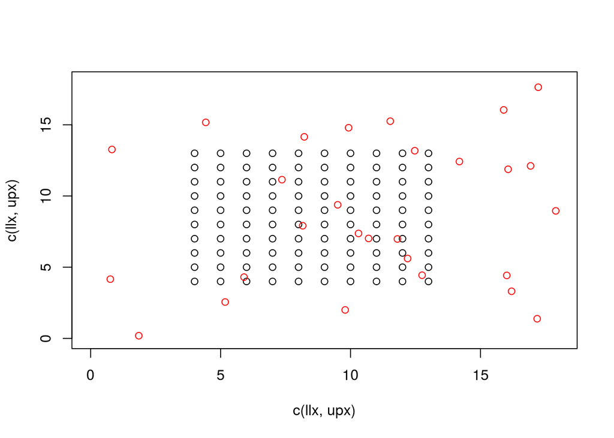

```r
plot(c(llx,upx), c(llx, upx), typ='n')
points(locs)
points(scrModel2$SX[1:28], scrModel2$SY[1:28], col = 'red')
```

Black points are cameras. Red dots are animal activity centers.

# Set up data and initial values for MCMC

Now that we’ve used the model for simulation, we want to mark the simulated `y` values as data and change other values to be naive.

We’ll also manually save some of the values to reset them later. (Alternatively, we could have used inits when defining the model to do this.)

```r
## We'll manually set initial values similarly to R&D
## This MCMC can fail if the initial values provide -Inf likelihood terms
scrModel2$sigma <- 5
scrModel2$lam0 <- lam0
scrModel2$psi <- 0.6
scrModel2$SX <- initSX <- runif(M, 4, 13) ## Unclear why R&D use runif(M, 2, 10)
scrModel2$SY <- initSY <- runif(M, 4, 13) ## ditto
scrModel2$z <- rbinom(M, 1, .5)
## not fully necessary, but it seems cleaner to set animals that were seen
## to definitely exist
scrModel2$z[ rowSums(scrModel2$y) > 0 ] <- 1
initZ <- scrModel2$z
scrModel2$setData(list(y = scrModel2$y))
```

# Default MCMC

First we’ll set up a default MCMC configuration.

```r
defaultMCMCconf <- configureMCMC(scrModel2, monitors = c('sigma','lam0','psi','N'))
## For illustration, let's look at samplers for a few nodes of each variable
defaultMCMCconf$printSamplers(c('sigma', 'lam0','psi','SX[1:3]', 'SY[1:3]', 'z[1:3]'))
```

```
## [1]   RW sampler: sigma
## [2]   RW sampler: lam0
## [3]   RW sampler: psi
## [4]   RW sampler: SX[1]
## [5]   RW sampler: SX[2]
## [6]   RW sampler: SX[3]
## [132] RW sampler: SY[1]
## [133] RW sampler: SY[2]
## [134] RW sampler: SY[3]
## [260] binary sampler: z[1]
## [261] binary sampler: z[2]
## [262] binary sampler: z[3]
```

# Observations about MCMC sampling for this model

The following points require some familiarity with how MCMC, and particularly Metropolis-Hastings, works.

- `SX[i]` and `SY[i]` are conceptually related and have the same dependencies.
- When `z[i]==0`, `SX[i]` and `SY[i]` follow their prior, and other calculations aren’t needed.
  - If animal `i` is not in the model, sampling `SX[i]` and `SY[i]` is wasted computation.
  - Would be better to propose new location values jointly when proposing `z[i]=1`
- It *might* be better to sample `lam0`, `sigma`, and `psi` more often than all the `z[i]`s.

*This example gives preliminary exploration of some of the kinds of considerations one might make to improve MCMC efficiency for this model. It is meant to illustrate what you can do with NIMBLE. It is not at all thorough or final.*

We’ll show two samplers that jointly handles a trio of `z[i]`, `SX[i]` and `SY[i]` as follows:

1. If `z[i]==1`, jointly sample `SX[i]` and `SY[i]`.
2. Sample `z[i]` as follows:
   - Only sample a given `z[i]` with probability 0.2 (a level chosen for illustration without any trials) on each iteration, to balance sampling effort.
   - If `z[i]==1`, propose `z[i] = 0` and avoid distance computations.
   - If `z[i]==0`, propose `z[i] = 1` and propose `SX[i]` and `SY[i]` from their priors. *This is recognizable as a Metropolis-Hastings sampler, but it can also be viewed as a reversible-jump sampler.*

# New sampler 1: Sample location only if indicator is 1

Here is our first new sampler:

```r
sampler_scr_locations <- nimbleFunction(
    contains = sampler_BASE, ## Class inheritance system
    setup = function(model, mvSaved, target, control) { ## required args
        ## target will be a vector like c('SX[3]','SY[3]')
        indicatorNode <- control$indicatorNode ## like 'z[3]'
        calcNodes <- model$getDependencies(target)
        ## The rest of this can be ignored:
        ## It is boilerplate for proposal scale adaptation
        scaleOriginal <- 1
        scale <- 1
        adaptive <- TRUE
        timesRan <- 0
        timesAccepted <- 0
        timesAdapted <- 0
        optimalAR <- 0.44 ## Actually this is for the 1D case instead of 2D
        gamma1    <- 0
        adaptInterval <- 100
    },
    run = function() {
        if(model[[indicatorNode]]==0) return() ## Skip location sampling

        ## Get current location (2 coordinates)
        location <- values(model, target)

        ## propose isotropically
        location[1] <- rnorm(1, mean = location[1], sd = scale)
        location[2] <- rnorm(1, mean = location[2], sd = scale)

        ## Put proposed location in model
        values(model, target) <<- location

        logMHR <- calculateDiff(model, calcNodes)
        accept <- decide(logMHR)
        if(accept)
            nimCopy(from = model, to = mvSaved, row = 1, nodes = calcNodes,
                         logProb = TRUE)
        else
            nimCopy(from = mvSaved, to = model, row = 1, nodes = calcNodes,
                         logProb = TRUE)
        if(adaptive) adaptiveProcedure(accept)
    },
    methods = list(
        ## from adaptive MCMC theory, copied from our RW sampler source code
        ## Should be modified since it is really a 2D sampler, but this will do
        ## for now
        adaptiveProcedure = function(jump = logical()) {
            timesRan <<- timesRan + 1
            if(jump)     timesAccepted <<- timesAccepted + 1
            if(timesRan %% adaptInterval == 0) {
                acceptanceRate <- timesAccepted / timesRan
                timesAdapted <<- timesAdapted + 1
                gamma1 <<- 1/((timesAdapted + 3)^0.8)
                gamma2 <- 10 * gamma1
                adaptFactor <- exp(gamma2 * (acceptanceRate - optimalAR))
                scale <<- scale * adaptFactor
                timesRan <<- 0
                timesAccepted <<- 0
            }
        },

        reset = function() {
            scale <<- scaleOriginal
            timesRan      <<- 0
            timesAccepted <<- 0
            timesAdapted  <<- 0
            gamma1 <<- 0
        })
)
```

There is another approach that would be cleaner but less illustrative for learning: The setup code could create a block sampler with identity covariance and adaptation only of the scale parameter. The run code could call that sampler when `z[i]==1`. This would take much less code and save us from copying adaptation code from NIMBLE’s source code. But for learning purposes we wanted to show more full-blown source code.

# Put the new samplers in an MCMC configuration

```r
customMCMCconf <- configureMCMC(scrModel2, nodes = c('lam0','sigma','psi'),
                                monitors = c('lam0','sigma','psi','N'))
customMCMCconf$printSamplers()
```

```
## [1] RW sampler: sigma
## [2] RW sampler: lam0
## [3] RW sampler: psi
```

```r
zNodes <- scrModel2$expandNodeNames('z')
SXnodes <- scrModel2$expandNodeNames('SX')
SYnodes <- scrModel2$expandNodeNames('SY')
## Illustrate what these vectors of node names look like
zNodes[1:3]
```

```
## [1] "z[1]" "z[2]" "z[3]"
```

```r
SXnodes[1:3]
```

```
## [1] "SX[1]" "SX[2]" "SX[3]"
```

```r
SYnodes[1:3]
```

```
## [1] "SY[1]" "SY[2]" "SY[3]"
```

```r
## add the samplers
for(i in 1:length(zNodes))
    customMCMCconf$addSampler(sampler_scr_locations,
                              target = c(SXnodes[i], SYnodes[i]),
                              control = list(indicatorNode = zNodes[i]))
## Illustrate that they have been added
customMCMCconf$printSamplers('SX[1:3]')
```

```
## [4] scr_locations sampler: SX[1], SY[1],  indicatorNode: z[1]
## [5] scr_locations sampler: SX[2], SY[2],  indicatorNode: z[2]
## [6] scr_locations sampler: SX[3], SY[3],  indicatorNode: z[3]
```

# New sampler 2: joint inclusion and location

Here is the joint sampler for inclusion (or indicator variable) and location:

```r
sampler_scr_inclusion <- nimbleFunction(
    contains = sampler_BASE, ## Class inheritance system
    setup = function(model, mvSaved, target, control) { ## required args
        ## target will be a vector like c('SX[3]','SY[3]')
        indicatorNode <- control$indicatorNode ## like 'z[3]'
        calcNodes <- model$getDependencies(c(target, indicatorNode))
        indicatorZeroCalcs <- model$getDependencies(indicatorNode)
        probDoSampler <- 0.2 # don't sample every indicator on every iteration
    },
    run = function() {
        if(runif(1,0,1) > probDoSampler) return()
        if(model[[indicatorNode]]==0) {
            ## propose putting in model
            currentLogProb <- model$getLogProb(indicatorZeroCalcs)
            model[[indicatorNode]] <<- 1
            model$simulate( target )
            proposalLogProb <- model$calculate(calcNodes)
            logProbForwardProposal <- model$getLogProb(target) ## proposal prob
            ## reversible jump / Metropolis-Hastings acceptance probability
            log_accept_prob <- proposalLogProb - currentLogProb
                                          - logProbForwardProposal
        } else {
            ## propose removing from model
            currentLogProb <- model$getLogProb(calcNodes)
            model[[indicatorNode]] <<- 0
            proposalLogProb <- model$calculate(indicatorZeroCalcs)
            logProbReverseProposal <- model$calculate(target)
            ## reversible jump / Metropolis-Hastings acceptance probability
            log_accept_prob <- proposalLogProb - currentLogProb
                                          + logProbReverseProposal
        }

        accept <- decide(log_accept_prob)
        ## There is a bit of excess copying here that could be reduced
        ## depending on which of the above cases was used
        ## but for simplicity I'm leaving it as is
        if(accept)
            copy(from = model, to = mvSaved, row = 1, nodes = calcNodes,
                         logProb = TRUE)
        else
            copy(from = mvSaved, to = model, row = 1, nodes = calcNodes,
                         logProb = TRUE)
    },
    methods = list(
            reset = function () {}
            )
)
```

# Put the second new samplers in an MCMC configuration

```r
for(i in 1:length(zNodes))
    customMCMCconf$addSampler(sampler_scr_inclusion,
                              target = c(SXnodes[i], SYnodes[i]),
                              control = list(indicatorNode = zNodes[i]))
## Illustrate that they were added
## Note that the z[i]s are sampled even though
## not provided via the "target" argument
customMCMCconf$printSamplers('SX[1:3]')
```

```
## [4]   scr_locations sampler: SX[1], SY[1],  indicatorNode: z[1]
## [5]   scr_locations sampler: SX[2], SY[2],  indicatorNode: z[2]
## [6]   scr_locations sampler: SX[3], SY[3],  indicatorNode: z[3]
## [132] scr_inclusion sampler: SX[1], SY[1],  indicatorNode: z[1]
## [133] scr_inclusion sampler: SX[2], SY[2],  indicatorNode: z[2]
## [134] scr_inclusion sampler: SX[3], SY[3],  indicatorNode: z[3]
```

# Compiling and running model and both samplers

We can compile the model and algorithms all together:

```r
defaultMCMC <- buildMCMC(defaultMCMCconf)
customMCMC <- buildMCMC(customMCMCconf)
compiled <- compileNimble(scrModel2, defaultMCMC, customMCMC)
```

Let’s run them:

```r
timeDefaultMCMC <- system.time(compiled$defaultMCMC$run(10000))
## To be fair, we'll reset states
compiled$scrModel2$SX <- initSX
compiled$scrModel2$SX <- initSY
compiled$scrModel2$SX <- initZ
compiled$scrModel2$sigma <- 5
compiled$scrModel2$lam0 <- lam0
compiled$scrModel2$psi <- 0.6
timeCustomMCMC <- system.time(compiled$customMCMC$run(10000))
```

Let’s look at results:

```r
i <- 1000:10000
## inspection of results shows they are similar
library(coda)
## How do the effective sample sizes compare?
effectiveSize(as.matrix(compiled$defaultMCMC$mvSamples)[i,])
```

```
##         N      lam0       psi     sigma
## 1274.8819  617.8068 1025.3656  474.0898
```

```r
effectiveSize(as.matrix(compiled$customMCMC$mvSamples)[i,])
```

```
##         N      lam0       psi     sigma
##  941.7104  598.9332 2090.3663  424.8703
```

```r
## How do the times compare?
timeDefaultMCMC
```

```
##    user  system elapsed
## 161.447   0.040 161.511
```

```r
timeCustomMCMC
```

```
##    user  system elapsed
##  94.123   0.043  94.247
```

```r
## How does MCMC efficiency compare?
effectiveSize(as.matrix(compiled$defaultMCMC$mvSamples)[i,])/timeDefaultMCMC[3]
```

```
##        N     lam0      psi    sigma
## 7.893468 3.825168 6.348581 2.935341
```

```r
effectiveSize(as.matrix(compiled$customMCMC$mvSamples)[i,])/timeCustomMCMC[3]
```

```
##         N      lam0       psi     sigma
##  9.991940  6.354931 22.179659  4.508051
```

It looks like the new samplers helped. Although scientific interest in this problem may focus on `N`, one wants all parameters to be well estimated in order to trust any results. For this reason we focus on the worst among the MCMC efficiencies, which has been improved by the custom samplers. Further improvements could likely be made.

[^1]: J. Andrew Royle and Robert M. Dorazio. 2009. Hierarchical Modeling and Inference in Ecology: The Analysis of Data from Populations, Metapopulations and Communities. Academic Press.